# TEMA 03 - Fiabilidad

01. Fiabilidad - Concepto

Miguel A. Castellanos López

## Fiabilidad

[figure not shown]

# Introducción

#### La fiabilidad es la consistencia de un instrumento ante repetidas aplicaciones del mismo

En Psicología al medir cambias el atributo: Aprendizaje, cansancio y maduración

En Psicología las diferencias en las puntuaciones se pueden deber a:

- Errores en la medición (errores de medida)
- Cambios reales en el atributo

También disponemos de métodos de consistencia interna

Pregunta de examen: ¿Los errores sistemáticos afectan la fiabilidad?

# Muy importante

Si no conoces la fiabilidad del test no sabes cómo de creíble es la puntuación que has obtenido

Podría ser todo error y nada de puntuación verdadera

Hay que ser siempre cautelosos al interpretar una puntuación de un test

#### Siempre, siempre, siempre, calcula el Intervalo de Confianza para la puntuación verdadera

# Coeficiente de Fiabilidad

La TCT define la fiabilidad como
$$\rho_{XV}^{2}=\frac{\sigma_{V}^{2}}{\sigma_{X}^{2}}$$

- Es el coeficiente de determinación de XV
- Es la proporción de la variación en X que se puede explicar (que depende) con la variación en V

Recuerda que como no puede ser calculado directamente, se calcula a través de la correlación entre dos test paralelos

$$\rho_{XX'}=\rho_{XV}^{2}=\frac{\sigma_{V}^{2}}{\sigma_{X}^{2}}$$

# Fiabilidad (*cont.*)

Como es un coeficiente de determinación se puede interpretar en el contexto de la regresión

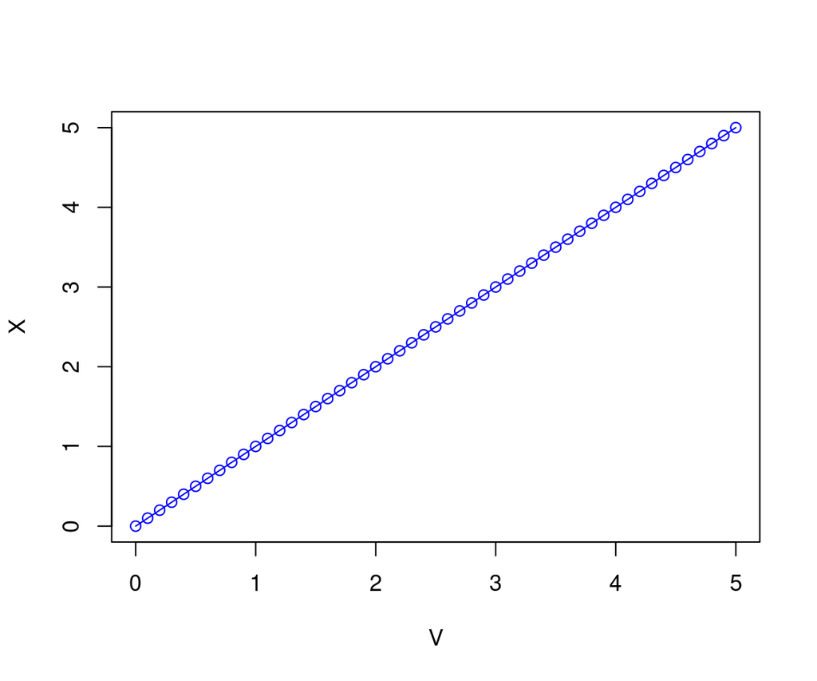

$$\rho_{XV}^{2}=1$$
$$X=V$$
$$E=0$$

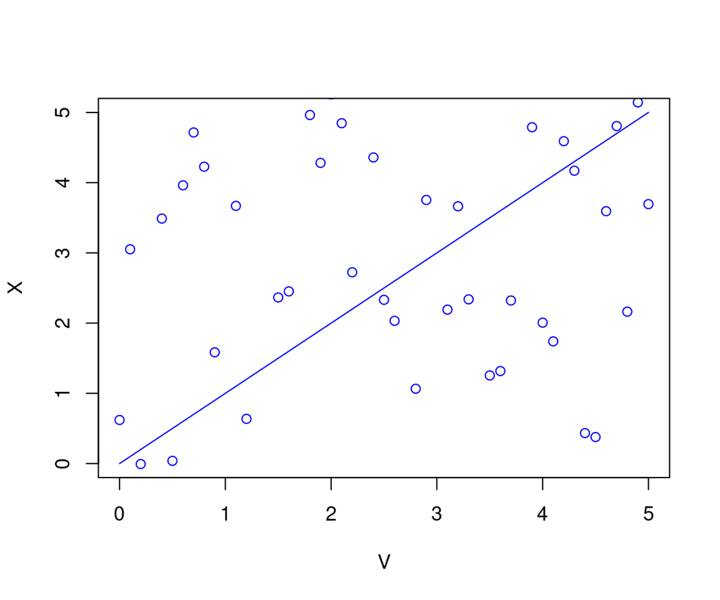

$$\rho_{XV}^{2}=0$$
$$X=E$$
$$V=0$$

# Fiabilidad (*cont.*)

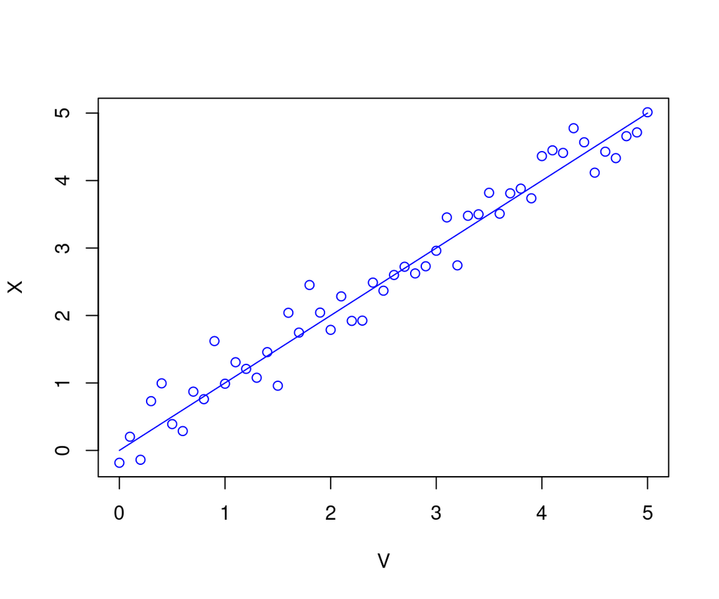

$$\rho_{XV}^{2}= [0 \dots 1]$$
$$X=V+E$$
$$V=X-E$$

| Valor | Interpretación |
| --- | --- |
| mayor 0.90 | Excelente |
| 0.80 - 0.89 | Muy buena |
| 0.70 - 0.79 | Buena |
| menor 0.70 | Interpretación cautelosa |

Esto siempre depende de los objetivos para los qué se usa el test: investigación, evaluación o diagnóstico

# Índice de Fiabilidad

Lo importante en la TCT es el **Coeficiente de Fiabilidad**

Pero en muchas fórmulas se utiliza el **Índice de Fiabilidad**

No es más que la raíz cuadrada del coeficiente

$$\textit{Coeficiente de Fiabilidad} \Rightarrow \rho_{XV}^{2}=\rho_{XX'}$$
$$\textit{Índice de Fiabilidad} \Rightarrow \rho_{XV}=\sqrt{\rho_{XX'}}$$

El significado de ambos es distinto:

- El coeficiente es un **coeficiente de determinación** (está al cuadrado) por la tanto es **la proporción de varianza explicada**
- El índice es **solo una correlación** (no está al cuadrado) por lo tanto es **solo la relación lineal** entre X y V

## Propiedades de la Fiabilidad

[figure not shown]

La Fiabilidad se ve afectada por distintos factores:

- La varianza de las muestras
- La longitud del test

# Fiabilidad y Varianza (*cont.*)

| Muestra 1 | Muestra 2 |
| --- | --- |
| Baja varianza | Alta varianza |
| $\sigma_{1}^{2}$ | $\sigma_{2}^{2}$ |
| $\rho_{11'}^{2}$ | $\rho_{22'}^{2}$ |

Entonces:

$$\rho_{22'}=1-\frac{\sigma_{X_{1}}^{2}}{\sigma_{X_{2}}^{2}}(1-\rho_{11'})$$

$$\sigma_{X_{2}}^{2}=\sigma_{X_{1}}^{2}\left(\frac{1-\rho_{11'}}{1-\rho_{22'}} \right)$$

Para que sea cierto debe cumplirse que:

$$\sigma_{E_{1}}^{2}=\sigma_{E_{2}}^{2}$$
pregunta: ¿Es creíble que se cumpla esta condición?

# Ejercicio:

En una muestra se ha encontrado que la fiabilidad es 0.64 y la varianza 36

1. Cuánto sería la fiabilidad si la varianza fuese 100
2. Cuánto tendría que ser la varianza de la segunda muestra para alcanzar una fiabilidad de 0.90

# Fiabilidad y Longitud

Introducir más items en el test

$\Rightarrow$ Aumento la muestra de conductas

$\Rightarrow$ Mejoro el muestreo de conductas

$\Rightarrow$ **Aumento la fiabilidad**

Se entiende que son items *paralelos* a los que ya hay

$$k=\frac{n'}{n}$$

$$\begin{array}{rcl}
n &\Rightarrow& n'
\\\rho_{xx'}&\Rightarrow&\rho_{XX'} = \frac{k\rho_{xx'}}{1+(k-1)\rho_{xx'}}\Leftarrow \textit{Spearman-Brown}
\\& &k=\frac{\rho_{XX'}(1-\rho_{xx'})}{\rho_{xx'}(1-\rho_{XX'})}
\\\mu_{x}&\Rightarrow&\mu_{X}=k\mu_{x}
\\\sigma_{x}^{2}&\Rightarrow&\sigma_{X}^{2}=k\sigma_{x}^{2}+k(k-1)\rho_{xx'}\sigma_{x}^{2}
\\\sigma_{v}^{2}&\Rightarrow&\sigma_{V}^{2}=k^{2}\sigma_{v}^{2}
\\\sigma_{e}^{2}&\Rightarrow&\sigma_{E}^{2}=k\sigma_{e}^{2}
\end{array}$$

La fórmula de *Spearman-Brown* (también se llama de la *profecía*) es muy importante en psicometría

# Ejercicio:

En un test de 40 elementos hemos obtenido que la media ha sido 25, la varianza empírica 36 y la fiabilidad 0.80.

1. Si aumentamos a 100 el número de elementos cuánto serán ahora todos los parámetros del test
2. Cuántos items tengo que añadir para obtener una fiabilidad de 0.95

# Manipulación de la fiabilidad

### Con la varianza

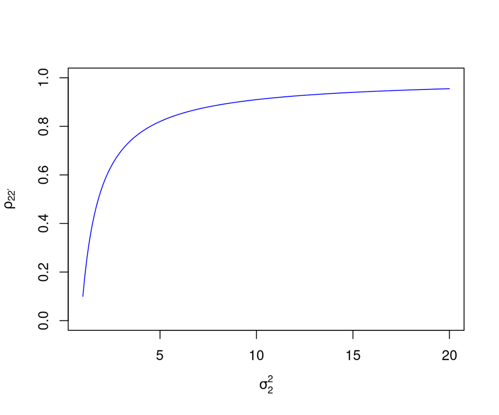

### Con la longitud

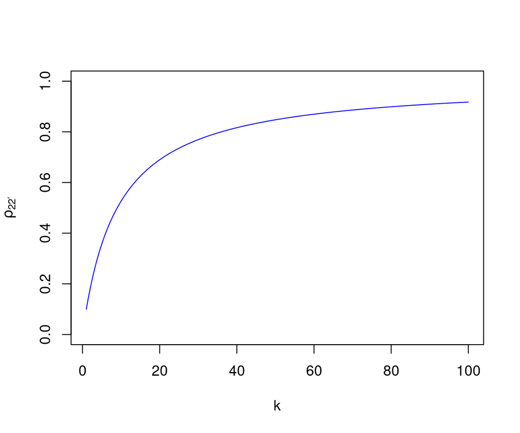

# Índices de Velocidad y Potencia

### Gulliksen

$$IV=\frac{\sigma_{F}^{2}}{\sigma_{I}^{2}}$$
$$I=F+O$$

Siendo:

- $F$:Fallos
- $O$:Omisiones
- $I$: Incorrectas

### Stafford

$$CV=\frac{\sum Ni}{\sum Ni+\sum O + \sum F}100$$

Siendo:

- $F$:Fallos
- $O$:Omisiones
- $Ni$: No intentados
- Gulliksen no diferencia entre Omisiones y No intentados, pero Stafford sí
- No se pueden calcular los métodos de consistencia interna con los test de velocidad

# Ejercicio de velocidad y potencia

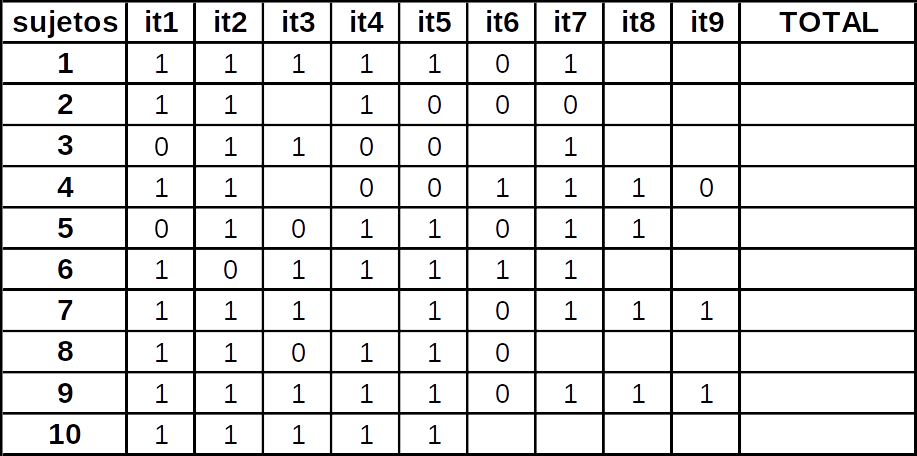